# Classification Bayésienne

Paul Cascarino et Mathis Quinio-Cosquer

Décembre 2023

# Projet 1 :

## 1. Introduction

### Les objectifs du projet

Le but de ce projet est de faire de la recherche dans le traitement du langage naturel et des émotions. Ainsi le principal objectif sera de faire de la prédiction sur les émotions à partir de textes.

## 2. Chargement et exploration des données

### Préparation et imports

Dans un premier temps, nous effaçons la mémoire :

```r
rm(list=ls())
```

Et faisons les chargements des packages nécessaires :

```r
#library(kableExtra)
library(e1071)
library(caret)
```

```r
library(ggplot2)
library(dplyr)
library(stringr)

# Permet la tokenization : https://smltar.com/tokenization#types-of-tokens
library(tokenizers)
# Permet l'utilisation de liste pour le stop-words : https://smltar.com/stopwords#premadestopwords
library(stopwords)
# Permet la stemmatization : https://smltar.com/stemming#how-to-stem-text-in-r
library(SnowballC)

#library(spacyr)
library(tm)
library(text2vec)
library(slam)

library(quanteda)
library(quanteda.textmodels)
```

### Chargement des données

Les données sont récupérés sur le site kaggle à l’adresse : https://www.kaggle.com/datasets/abdallahwagih/emotion-dataset Nous pouvons ainsi récupérer le csv récupéré avec :

```r
df <- read.csv('data/Emotion_classify_Data.csv')
#df <- df[0:500,]
```

Voici un aperçu de nos données :

```r
head(df)
```

```
##                                                                                                                               Comment
## 1                                                           i seriously hate one subject to death but now i feel reluctant to drop it
## 2                                                                                                  im so full of life i feel appalled
## 3 i sit here to write i start to dig out my feelings and i think that i am afraid to accept the possibility that he might not make it
## 4                                           ive been really angry with r and i feel like an idiot for trusting him in the first place
## 5                                             i feel suspicious if there is no one outside like the rapture has happened or something
## 6                           i feel jealous becasue i wanted that kind of love the true connection between two souls and i wanted that
##   Emotion
## 1    fear
## 2   anger
## 3    fear
## 4     joy
## 5    fear
## 6   anger
```

### Analyse exploratoire des données

```r
dim(df)
```

```
## [1] 5937    2
```

```r
colnames(df)
```

```
## [1] "Comment" "Emotion"
```

Nous remarquons qu’il n’y a pas d’éléments dupliqués :

```r
sum(duplicated(df))
```

```
## [1] 0
```

Nous remarquons aussi qu’il n’y a pas d’éléments nuls

```r
sum(is.na(df))
```

```
## [1] 0
```

#### Regardons la colonne `Comment`, les textes :

```r
df$Comment[500:503]
```

```
## [1] "i am feeling the need to consolidate to step back and re evaluate the purpose of this blog other than providing a fabulous vicarious life for yall to live through my sarcasm does not always come across in print"
## [2] "i don t feel like there was a part before the race where i was stressed out"
## [3] "ive been feeling disgusted and ashamed"
## [4] "i don t just mean that the sensations we experience influence our moods i m not simply pointing out that say discomfort in our bodies makes us feel irritable"
```

Nous avons donc des textes écrits en anglais avec des mots qui semblent être récurrents, tel que `feel` et ce qui tourne autour des sentiments.

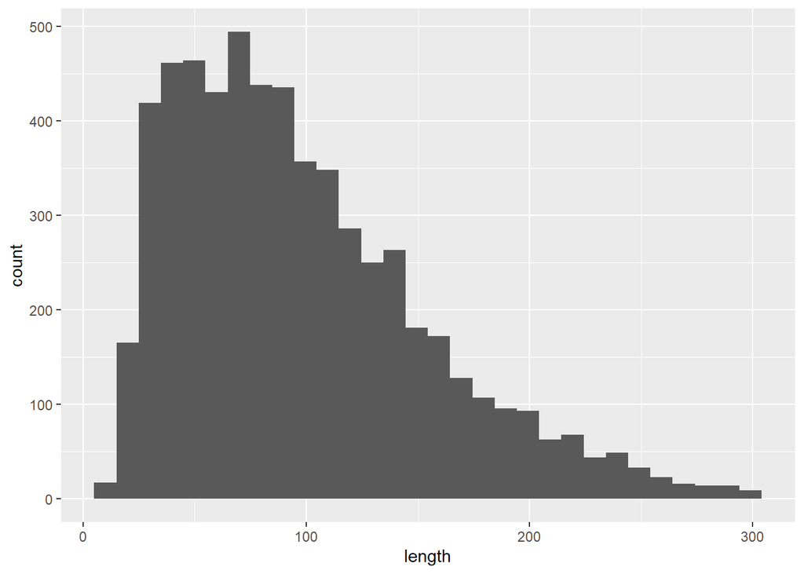

```r
nchar_df <- data.frame(length = nchar(df$Comment))

plot <- ggplot(nchar_df, aes(x = length)) + geom_histogram()

plot
```

Nous remarquons avec la distribution que nous ne disposons probablement pas de textes avec des longueurs aberrantes.

#### Regardons la colonne `Emotion`, les émotions :

```r
emotion <- factor(df$Emotion)
levels(emotion)
```

```
## [1] "anger" "fear"  "joy"
```

nous avons donc 3 émotions de diposibles qui sont : `anger`, `fear`et `joy`.

Créons un graphique qui rend plus visuel la répartition des émotions :

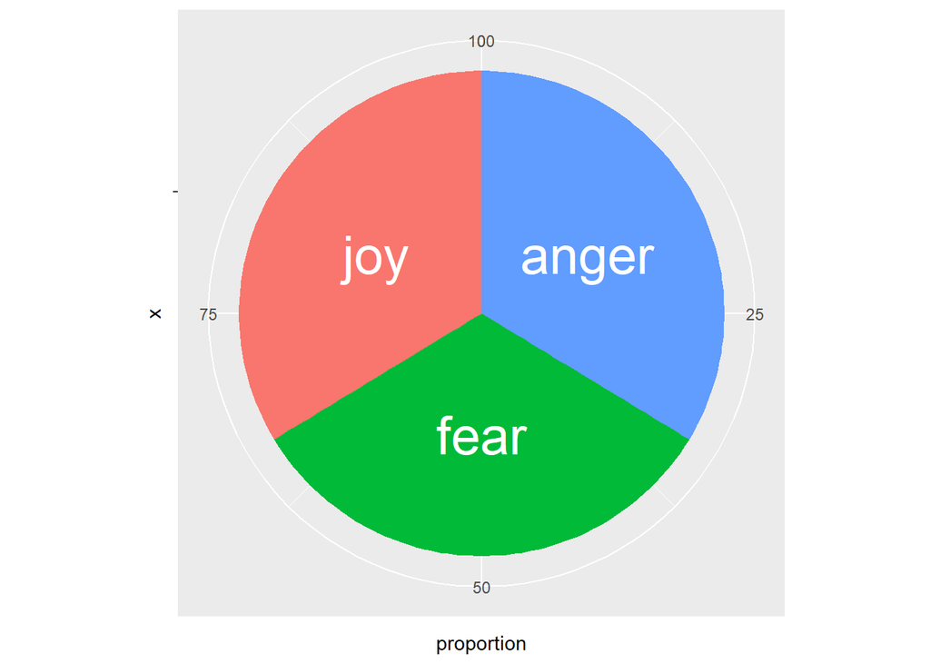

```r
pie_chart <- function(emotion) {
  emotion_df <- data.frame(
    Count = table(emotion)
  )
  colnames(emotion_df) <- c('Emotion', 'Count')

  emotion_df <- emotion_df %>%
                  mutate(proportion = Count / sum(emotion_df$Count) * 100) %>%
                  mutate(ypos = cumsum(proportion)- 0.5*proportion)

  pie_chart <- ggplot(emotion_df, aes(x='', y=proportion, fill=Emotion)) +
                geom_bar(stat='identity', width=1) +
                coord_polar('y', start=0) +
                theme(legend.position='none') +
                geom_text(aes(x ='', y=ypos, label=Emotion), color='white', size = 10)

  pie_chart
}

pie_chart(emotion)
```

Nous remarquons que la répartition des 3 émotions est quasiment identiques.

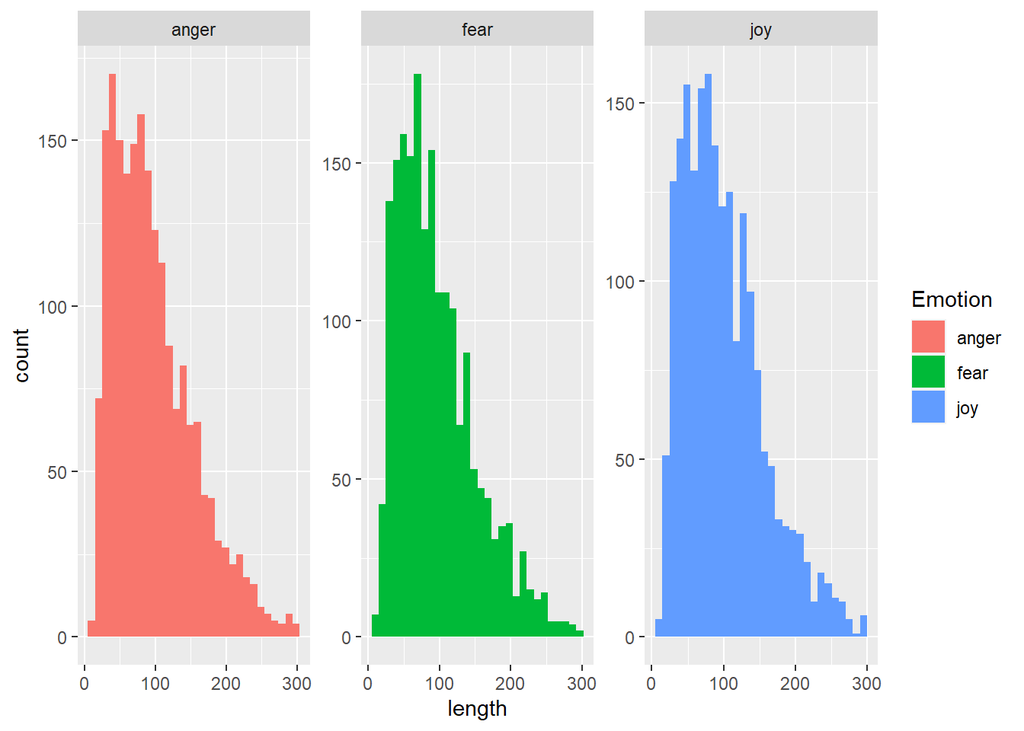

```r
nchar_df <- data.frame(length = nchar(df$Comment), Emotion = df$Emotion)

plot <- ggplot(nchar_df, aes(x=length, fill=Emotion)) +
          geom_histogram(position='identity') +
          facet_wrap(~Emotion, scales='free')

plot
```

Nous remarquons que la répartition des longeurs des chaînes de caractères sont similaires en fonction des émotions

## 3. Prétraitement des données

### Suppression des caractères spéciaux et chiffres

```r
# On mets en minuscule nos commentaires (au cas où)
df$Comment <- str_to_lower(df$Comment)

nbr_comment_false_char <- sum( ! str_detect(df$Comment, '[[:alnum:]]') == TRUE)
nbr_comment_num <- sum(str_detect(df$Comment, '^[0-9]') == TRUE)
nbr_comment_with_punct <- sum(str_detect(df$Comment, '[[:punct:]]') == TRUE)

cat('Nombre de caractères non alphanumériques :', nbr_comment_false_char,'\n')
```

```
## Nombre de caractères non alphanumériques : 0
```

```r
cat('Nombre de chiffres :', nbr_comment_num,'\n')
```

```
## Nombre de chiffres : 0
```

```r
cat('Nombre de caractères de ponctuation :', nbr_comment_with_punct,'\n')
```

```
## Nombre de caractères de ponctuation : 0
```

**Explication :**

Nous avons 0 caractères non alphanumériques, 0 chiffres et 0 de ponctuations. Les caractères sont tous en minuscules, nous pouvons donc regarder si il y a des mots vides et appliquer la tokenization.

### Tokenization, stemming ou lemmatization

#### Tokenization

https://smltar.com/tokenization

Nous décidons dans un premier temps de faire une tokenization par mots car c est la méthode la plus commune et que cela nous parait logique de travailler dans un premier temps avec les mots.

```r
df$tokenize_1words <- tokenize_words(df$Comment)
df$tokenize_2words <- tokenize_ngrams(df$Comment, n=2)
df$tokenize_3words <- tokenize_ngrams(df$Comment, n=3)
df$tokenize_2words_min <- tokenize_ngrams(df$Comment, n=2, n_min=1)
df$tokenize_3words_min <- tokenize_ngrams(df$Comment, n=3, n_min=1)
head(df$tokenize_1words)
```

```
## [[1]]
##  [1] "i"         "seriously" "hate"      "one"       "subject"   "to"
##  [7] "death"     "but"       "now"       "i"         "feel"      "reluctant"
## [13] "to"        "drop"      "it"
##
## [[2]]
## [1] "im"       "so"       "full"     "of"       "life"     "i"        "feel"
## [8] "appalled"
##
## [[3]]
##  [1] "i"           "sit"         "here"        "to"          "write"
##  [6] "i"           "start"       "to"          "dig"         "out"
## [11] "my"          "feelings"    "and"         "i"           "think"
## [16] "that"        "i"           "am"          "afraid"      "to"
## [21] "accept"      "the"         "possibility" "that"        "he"
## [26] "might"       "not"         "make"        "it"
##
## [[4]]
##  [1] "ive"      "been"     "really"   "angry"    "with"     "r"
##  [7] "and"      "i"        "feel"     "like"     "an"       "idiot"
## [13] "for"      "trusting" "him"      "in"       "the"      "first"
## [19] "place"
##
## [[5]]
##  [1] "i"          "feel"       "suspicious" "if"         "there"
##  [6] "is"         "no"         "one"        "outside"    "like"
## [11] "the"        "rapture"    "has"        "happened"   "or"
## [16] "something"
##
## [[6]]
##  [1] "i"          "feel"       "jealous"    "becasue"    "i"
##  [6] "wanted"     "that"       "kind"       "of"         "love"
## [11] "the"        "true"       "connection" "between"    "two"
## [16] "souls"      "and"        "i"          "wanted"     "that"
```

Nous décidons d appliquer différents N-gram tokenization afin d évaluer plus tard les différences sur les performances de notre modèle.

Nous pouvons maintenant observer les tokens les plus utilisés :

```r
give_most_words <- function(df_tokens, col_names, n){
  token_freq <- table(unlist(df_tokens[[col_names]]))
  token_freq_df <- data.frame(token = names(token_freq), frequency = as.numeric(token_freq))
  token_freq_df <- token_freq_df[order(-token_freq_df$frequency),]
  plot <- ggplot(token_freq_df[0:n,], aes(x=reorder(token, -frequency), y=frequency)) +
            geom_bar(stat = 'identity')
  return(list(plot=plot, df=token_freq_df))
}
```

Pour 1 mot :

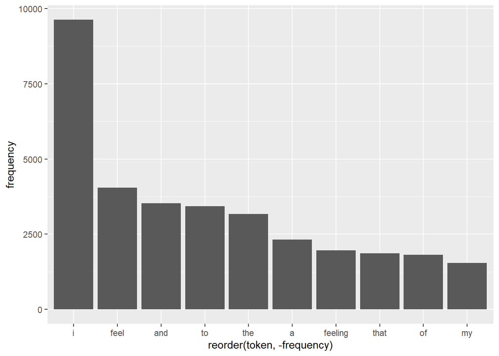

```r
result <- give_most_words(df[, c('tokenize_1words', 'Emotion')], 'tokenize_1words', 10)
result$plot
```

Pour 2 mots :

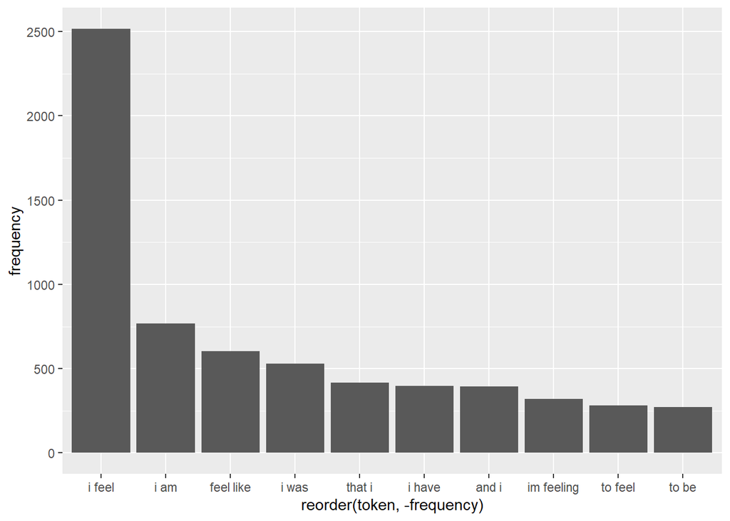

```r
result <- give_most_words(df[, c('tokenize_2words', 'Emotion')], 'tokenize_2words', 10)
result$plot
```

Pour 3 mots :

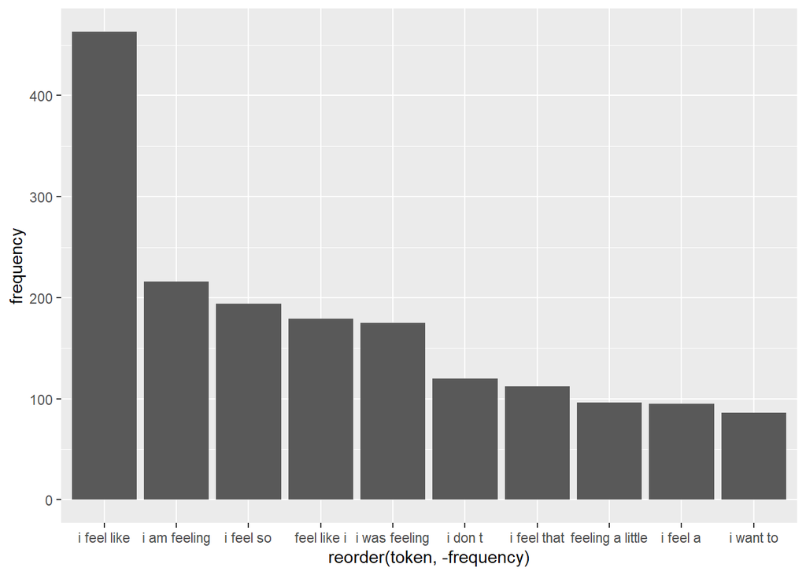

```r
result <- give_most_words(df[, c('tokenize_3words', 'Emotion')], 'tokenize_3words', 10)
result$plot
```

**Explication :**

Nous avons définit une fonction qui permet de retourner un graph des n premiers mots et longeurs fréquences d apparition dans notre df.

#### Regardons maintenant les stop words

Les **stop words** sont les mots qui n ont pas d intérêts dans le sens de la phrase. Ansi les supprimer réduirait le nombre de feature et donc le nombre de calculs. Nous pouvons aussi penser que réduire les mots inutiles réduirait la performance de notre futur modèle.

```r
head(stopwords::stopwords(source = "snowball"))
```

```
## [1] "i"      "me"     "my"     "myself" "we"     "our"
```

Nous allons dans un premier temps travailler avec notre tokenization à 1 mot

```r
temp_df <- df$tokenize_1words
# Suppose que temp_df est une liste de vecteurs de mots
df$t1_snow<- lapply(temp_df, function(x) x[!(x %in% stopwords::stopwords(source = "snowball"))])
df$t1_smart<- lapply(temp_df, function(x) x[!(x %in% stopwords::stopwords(source = "smart"))])
df$t1_iso<- lapply(temp_df, function(x) x[!(x %in% stopwords::stopwords(source = "stopwords-iso"))])

cat("Nombre de mots avant l'étape des stop words : ",
sum(lengths(temp_df)))
```

```
## Nombre de mots avant l'étape des stop words :  114308
```

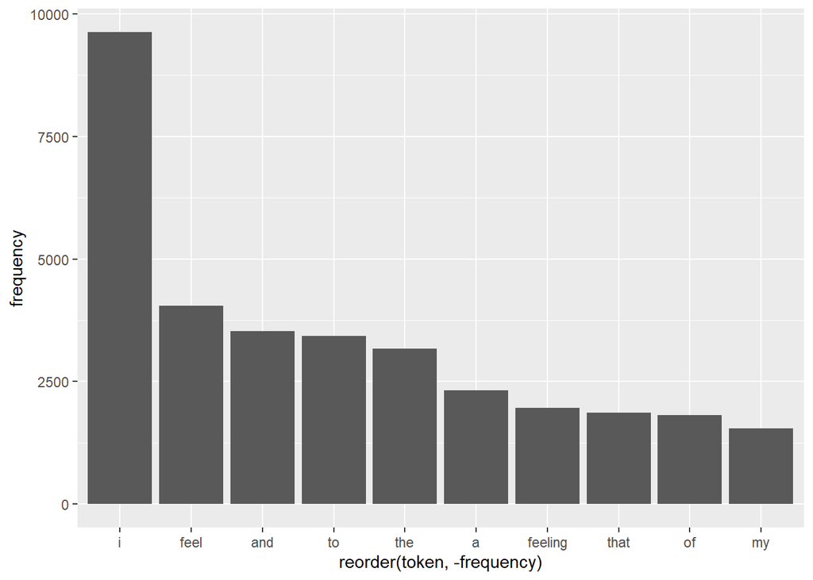

```r
result <- give_most_words(df[, c('tokenize_1words', 'Emotion')], 'tokenize_1words', 10)
result$plot
```

```r
cat("Nombre de mots après l'étape des stop words pour t1_snow: ",
sum(lengths(df$stop1)))
```

[output not shown]

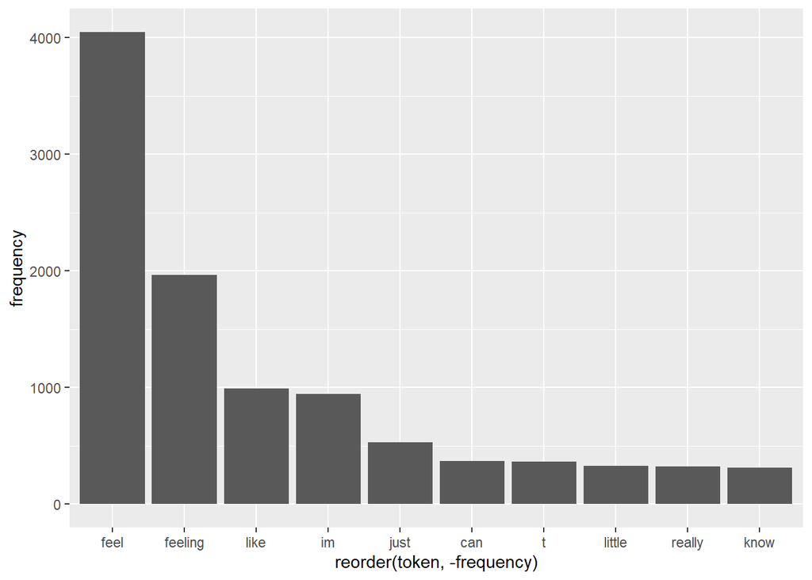

```r
result <- give_most_words(df[, c('t1_snow', 'Emotion')], 't1_snow', 10)
result$plot
```

```r
cat("Nombre de mots après l'étape des stop words pour t1_smart: ",
sum(lengths(df$stop1)))
```

[output not shown]

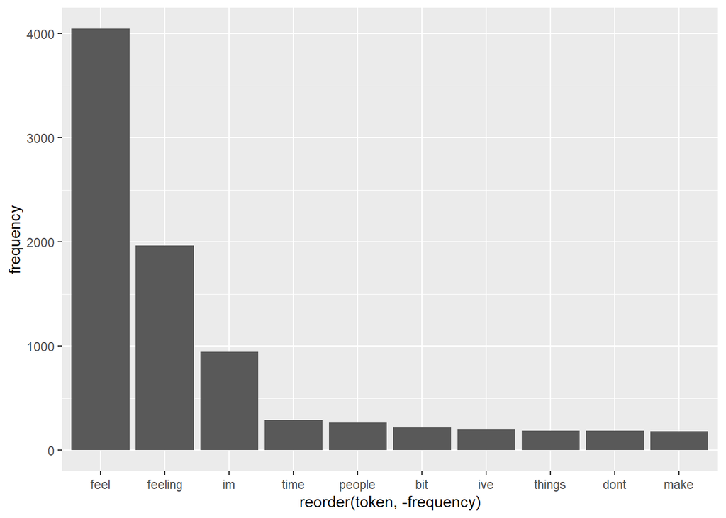

```r
result <- give_most_words(df[, c('t1_smart', 'Emotion')], 't1_smart', 10)
result$plot
```

```r
cat("Nombre de mots après l'étape des stop words pour t1_iso: ",
sum(lengths(df$stop1)))
```

[output not shown]

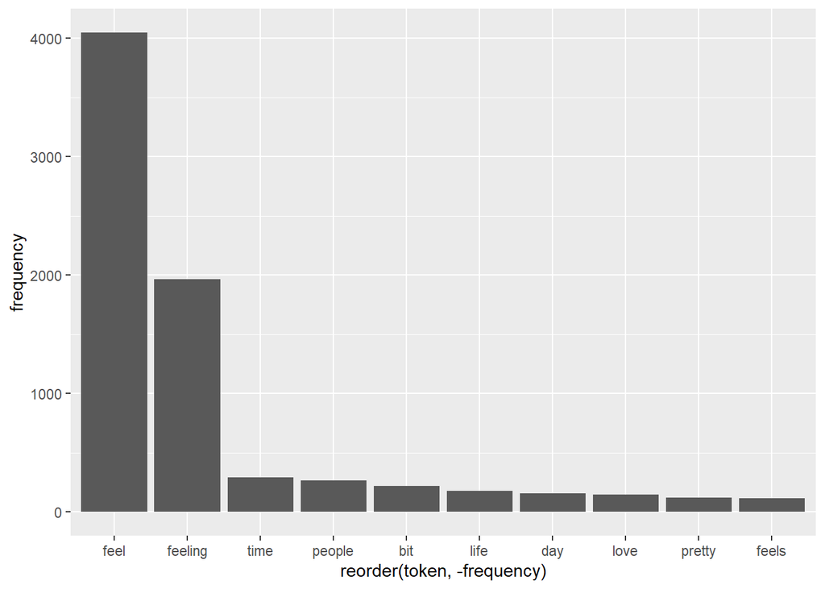

```r
result <- give_most_words(df[, c('t1_iso', 'Emotion')], 't1_iso', 10)
result$plot
```

#### Stemming

Le stemming permet de rapprocher les mots similaires tel que ‘feel’ et ‘feels’ en un stem qui est un mot de base (ex:‘feel’).

```r
snow_df <- df$t1_snow
smart_df <- df$t1_smart
iso_df <- df$t1_iso

# Applique la fonction wordStem à chaque vecteur de mots dans la liste
df$t1_snow_stem <- lapply(snow_df, function(x) wordStem(x))
df$t1_smart_stem <- lapply(smart_df, function(x) wordStem(x))
df$t1_iso_stem <- lapply(iso_df, function(x) wordStem(x))

cat("Nombre de mots avant la stematization : ",
sum(lengths(snow_df)))
```

```
## Nombre de mots avant la stematization :  57557
```

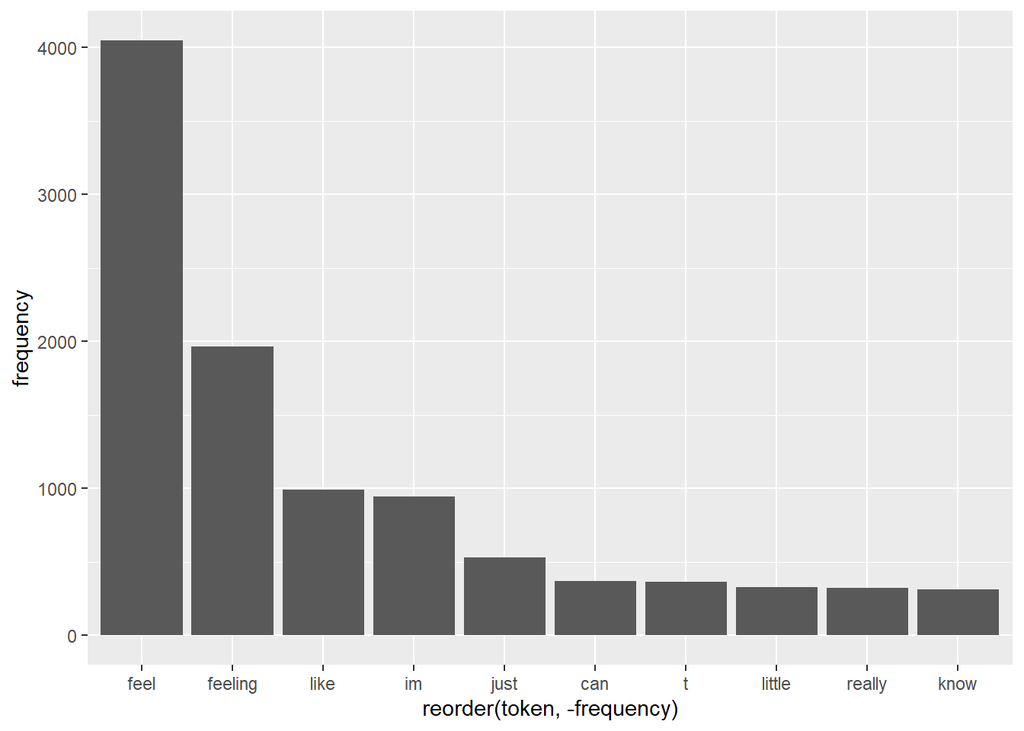

```r
result <- give_most_words(df[, c('t1_snow', 'Emotion')], 't1_snow', 10)
result$plot
```

```r
cat("Nombre de mots après la stematization pour t1_snow : ",
sum(lengths(df$t1_snow_stem)))
```

```
## Nombre de mots après la stematization pour t1_snow :  57557
```

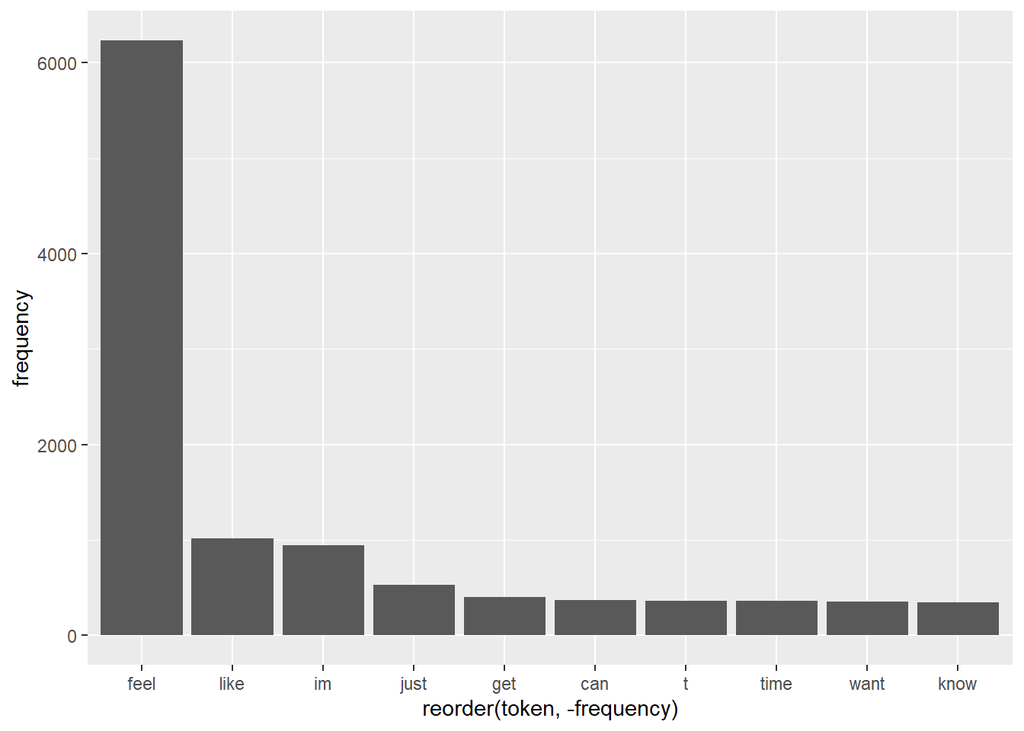

```r
result <- give_most_words(df[, c('t1_snow_stem', 'Emotion')], 't1_snow_stem', 10)
result$plot
```

```r
cat("Nombre de mots après la stematization pour t1_smart : ",
sum(lengths(df$t1_smart_stem)))
```

```
## Nombre de mots après la stematization pour t1_smart :  43650
```

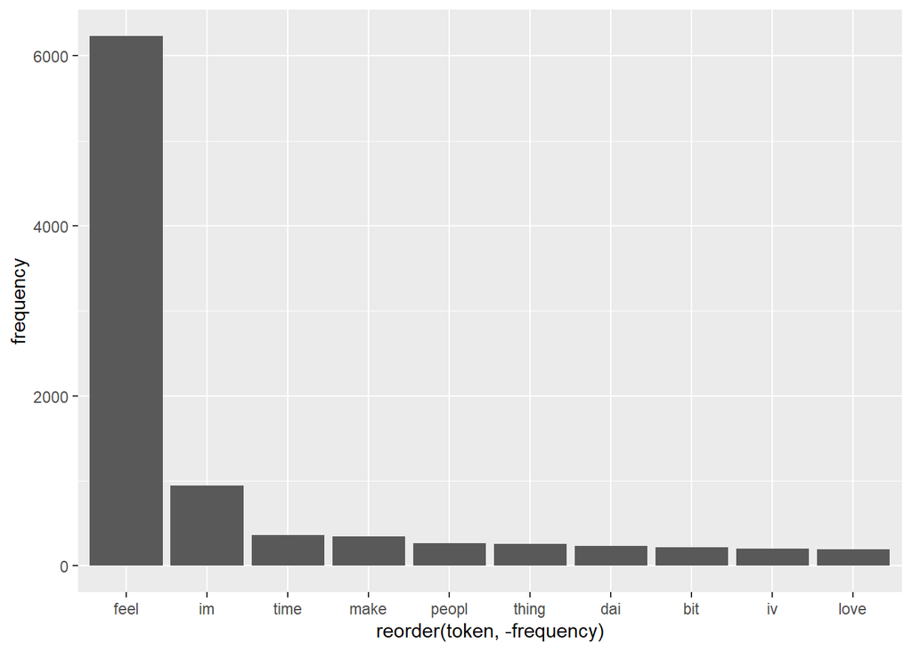

```r
result <- give_most_words(df[, c('t1_smart_stem', 'Emotion')], 't1_smart_stem', 10)
result$plot
```

```r
cat("Nombre de mots après la stematization pour t1_iso : ",
sum(lengths(df$t1_iso_stem)))
```

```
## Nombre de mots après la stematization pour t1_iso :  36690
```

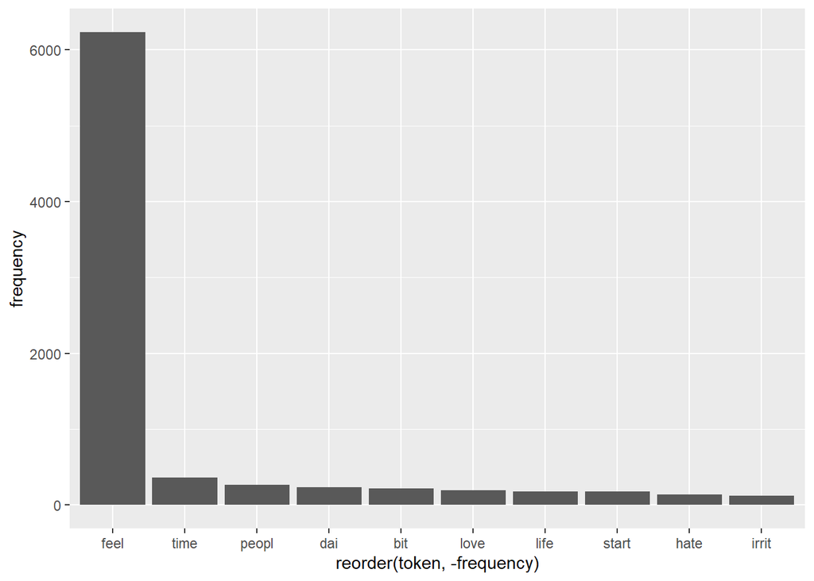

```r
result <- give_most_words(df[, c('t1_iso_stem', 'Emotion')], 't1_iso_stem', 10)
result$plot
```

Nous remarquons que **feel** comporte maintenant par exemple **feel** et **feeling**. Cela fonctionne bien et réduit le nombre de mots différents.

#### TF-IDF

On a :
$$\text{IDF}(t, D) = \log\left(\frac{N}{\text{df}(t)}\right)$$
avec

- N : le nombre documents total
- df(t) : le nombre de documents comportant le terme t

Ainsi IDF(t,D) donne le poids IDF du terme t dans les documents de D. Cela correspond à l importance du mot dans notre corpus de documents.

```r
temp_df <- df$t1_iso_stem

temp_df_corpus <- Corpus(VectorSource(temp_df))

# Créer un Document-Term Matrix (DTM)
temp_df_dtm <- DocumentTermMatrix(temp_df_corpus)

# Convertir la DTM en matrice creuse (sparse matrix)
temp_df_sparse <- as.matrix(temp_df_dtm)

# TF IDF
tfidf <- weightTfIdf(temp_df_dtm)
#

tfidf
```

```
## <<DocumentTermMatrix (documents: 5937, terms: 8391)>>
## Non-/sparse entries: 36054/49781313
## Sparsity           : 100%
## Maximal term length: 21
## Weighting          : term frequency - inverse document frequency (normalized) (tf-idf)
```

## 4. Entrainement du modèle bayésien

Définition du test set et train set :

```r
set.seed(14)

# Définir le pourcentage des données d'entraînement sur le total
percentage_train <- 0.7

train_indices <- sample(1:nrow(tfidf), floor(percentage_train * nrow(tfidf)))


X_train <- as.matrix(tfidf[train_indices, ])
X_test <- as.matrix(tfidf[-train_indices, ])
y_train <- factor(df$Emotion[train_indices])
y_test <- factor(df$Emotion[-train_indices])


cat("Taille de l'ensemble d'entraînement :",
nrow(X_train), length(y_train))
```

```
## Taille de l'ensemble d'entraînement : 4155 4155
```

```r
cat("Taille de l'ensemble de test :",
nrow(X_test), length(y_test))
```

```
## Taille de l'ensemble de test : 1782 1782
```

```r
# model <- naiveBayes(X_train, y_train)

# predictions <- predict(model, X_test)

# table_confusion <- table(predictions, y_test)

# accuracy <- sum(predictions == y_test) / length(y_test)
```

Création de la fonction qui teste tout le modèle à partir d un preprocessing différent :

```r
test_bayesian <- function(df_temp, df){
  temp_df <- df_temp
  #print(temp_df)
  temp_df_corpus <- Corpus(VectorSource(temp_df))


  temp_df_dtm <- DocumentTermMatrix(temp_df_corpus)

  temp_df_sparse <- as.matrix(temp_df_dtm)
  print(temp_df_sparse)
  #print(temp_df_sparse)

  # TF IDF
  tfidf <- weightTfIdf(temp_df_dtm)

  #print(tfidf)
  set.seed(1)

  # Définir le pourcentage des données d'entraînement sur le total
  percentage_train <- 0.7

  train_indices <- sample(1:nrow(temp_df_sparse), floor(percentage_train * nrow(temp_df_sparse)))

  X_train <- as.matrix(tfidf[train_indices, ])
  X_test <- as.matrix(tfidf[-train_indices, ])
  y_train <- factor(df$Emotion[train_indices])
  y_test <- factor(df$Emotion[-train_indices])

  model <- naiveBayes(X_train, y_train)

  predictions <- predict(model, X_train)
  #print(y_train)
  #table_confusion <- table(predictions, y_train)

  #accuracy <- sum(predictions == y_test) / length(y_test)

  #print(X_test)
  #print(predictions)
  #print(table_confusion)
  # print(accuracy)

}
```

```r
test_bayesian2 <- function(df_temp, df, term_count_min, seed){
  temp_df <- df_temp

  set.seed(seed)

  # Définir le pourcentage des données d'entraînement sur le total
  percentage_train <- 0.70

  train_indices <- sample(1:length(temp_df), floor(percentage_train * length(temp_df)))


  X_train <- as.matrix(temp_df[train_indices])
  X_test <- as.matrix(temp_df[-train_indices])
  y_train <- factor(df$Emotion[train_indices])
  y_test <- factor(df$Emotion[-train_indices])


  itoken_train <- itoken(X_train)
  itoken_test <- itoken(X_test)


  vocabulary <- create_vocabulary(itoken_train)
  vocabulary <- prune_vocabulary(vocabulary, term_count_min)

  vectorizer <- vocab_vectorizer(vocabulary)

  dtm_train <- create_dtm(itoken_train, vectorizer)
  dtm_test <- create_dtm(itoken_test, vectorizer)

  train_matrix <- as.matrix(as(dtm_train, "CsparseMatrix"))
  test_matrix <- as.matrix(as(dtm_test, "CsparseMatrix"))

  model <- naiveBayes(train_matrix, y_train)

  predictions <- predict(model, test_matrix)

  accuracy <- sum(predictions == y_test) / length(y_test)
  confusion <- confusionMatrix(predictions, y_test)
  return(accuracy)
  print(confusion)
}
```

### 5. Evaluation et amélioration du modèle

Nous testons maintenant notre modèle sur tous le préprocessing crées.

Pour ne pas avoir un runtime énome nous avons mis nos modèles en commentaires.

Maais chacun a été testé et le meilleur est test_bayesian2(df$t1_smart_stem, df, j, i)

```r
# test_bayesian2(df$tokenize_1words[1:500], df[1:500,])
# test_bayesian2(df$tokenize_2words[1:500], df[1:500,])
# test_bayesian2(df$tokenize_3words[1:500], df[1:500,])
# test_bayesian2(df$t1_snow[1:500], df[1:500,])
# test_bayesian2(df$t1_smart[1:500], df[1:500,])
# test_bayesian2(df$t1_iso[1:500], df[1:500,])
# test_bayesian2(df$t1_snow_stem[1:500], df[1:500,])
# test_bayesian2(df$t1_smart_stem[1:500], df[1:500,])
test_bayesian2(df$t1_smart_stem, df, 15,35)
```

```
## [1] 0.5735129
```

Permet l’amélioration du modèle :

```r
# seq_seed <- seq(1, 100, by = 10)
# seq_min <- seq(5, 25, by = 5)
# accuracy_values <- c()
# for (j in seq_min){
#   print(j)
#   for(i in seq_seed){
#     accuracy <- test_bayesian2(df$t1_smart_stem, df, j, i)

#     print(accuracy)
#     accuracy_values <- c(accuracy_values, accuracy)
#   }
#   print(mean(accuracy))
# }
```

## 6. Conclusion et travaux à venir

### Améliorations possibles

Nous n’avons pas eu le temps de faire la validation croisé de manière convenable ainsi que la présentation des résultats. Nous nous sommes donc concentrés sur le travail en fouille et permettre d’obtenir le meilleur preprocessing car les aspects manquants sont dévelopés dans d’autres matières. (en python).